# PairwiseStatistics

Asgard Andres Mendoza Flores

2024-11-30

```r
Norte_2 <- read.csv("00.csv")
Noroeste <- read.csv("02.csv")
Sureste <- read.csv("03.csv")
Centro <- read.csv("04.csv")

#Se hace una lista con todas las estaciones que se piensan analizar
#tables será usado para análisis detallados de cada estación
tables = list(Norte_2,Noroeste,Sureste,Centro)
```

Actualmente sólo se está trabajando con la estación “Norte_2”

```r
date_formating <- function(df)
{
  df[[1]] <- as.POSIXct(df[[1]], tz=Sys.timezone())
  names(df)[1] <- "date"
  return(df)
}
tables= lapply(tables,date_formating)
```

```r
summary(tables[[1]])
```

```
##       date                           NO              NO2
##  Min.   :2023-01-01 00:00:00   Min.   :  0.80   Min.   :  0.4
##  1st Qu.:2023-05-25 00:00:00   1st Qu.:  5.00   1st Qu.: 15.2
##  Median :2023-10-17 00:00:00   Median :  9.60   Median : 21.5
##  Mean   :2023-10-16 13:44:33   Mean   : 20.43   Mean   : 23.7
##  3rd Qu.:2024-03-09 00:00:00   3rd Qu.: 25.70   3rd Qu.: 29.5
##  Max.   :2024-07-31 00:00:00   Max.   :339.90   Max.   :126.0
##        O3              PM10            PM2.5             WSR
##  Min.   :  1.00   Min.   :  2.00   Min.   :  1.00   Min.   : 0.100
##  1st Qu.: 14.00   1st Qu.: 39.00   1st Qu.: 10.00   1st Qu.: 5.400
##  Median : 22.00   Median : 58.00   Median : 18.00   Median : 7.300
##  Mean   : 26.73   Mean   : 66.28   Mean   : 21.07   Mean   : 7.633
##  3rd Qu.: 35.00   3rd Qu.: 82.00   3rd Qu.: 29.00   3rd Qu.: 9.500
##  Max.   :163.00   Max.   :705.00   Max.   :418.00   Max.   :27.700
##       WDV
##  Min.   :  1.0
##  1st Qu.: 42.0
##  Median : 78.0
##  Mean   : 99.4
##  3rd Qu.:105.0
##  Max.   :360.0
```

Se determinan los intervalos de fechas exactos para los que se realizará el PolarPlot

```r
library(openair)
data=tables[[1]]
data <- cutData(data, type = "season")

print(unique(data$season))
```

```
## [1] winter (DJF) spring (MAM) summer (JJA) autumn (SON)
## Levels: spring (MAM) < summer (JJA) < autumn (SON) < winter (DJF)
```

```r
spring_data <- subset(data, season =="spring (mam)")
summer_data <- subset(data, season == "summer (jja)")
autumn_data <- subset(data, season== "autumn (son)")
winter_data <- subset(data, season == "winter (def)")
```

A esta función faltaría agregarle los datos separados por las estaciones “correctas”.

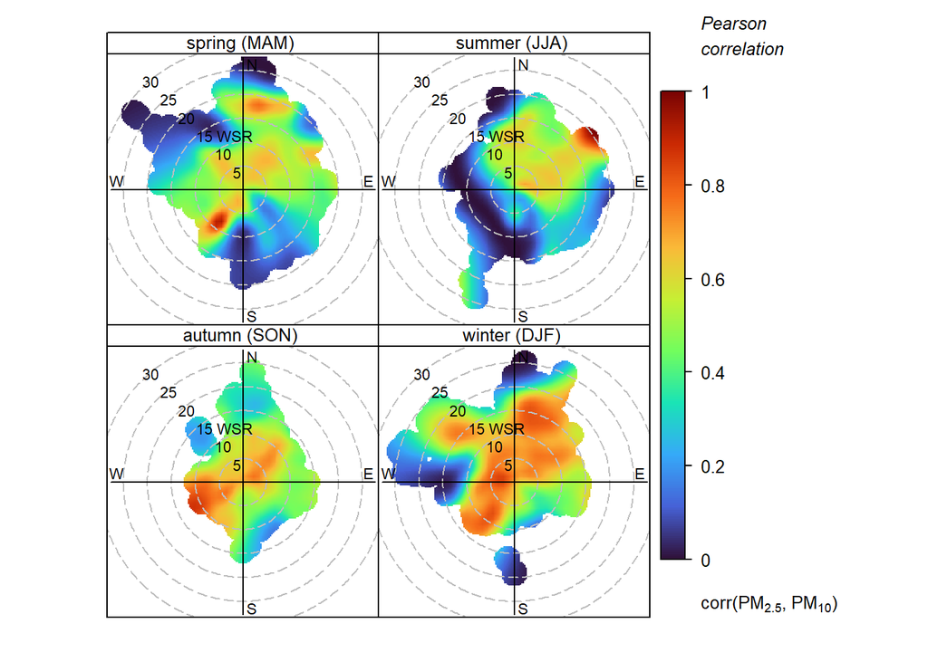

```r
library(openair)
polarPlot(tables[[1]],
          poll=c("PM2.5", "PM10"),
          statistic= "Pearson",
          col="turbo",
          limits=c(0,1),
          x="WSR", wd="WDV",
          type="season",
          ws_spread=2.5,
          wd_spread=10)
```

## Filtrar Datos para Regresión

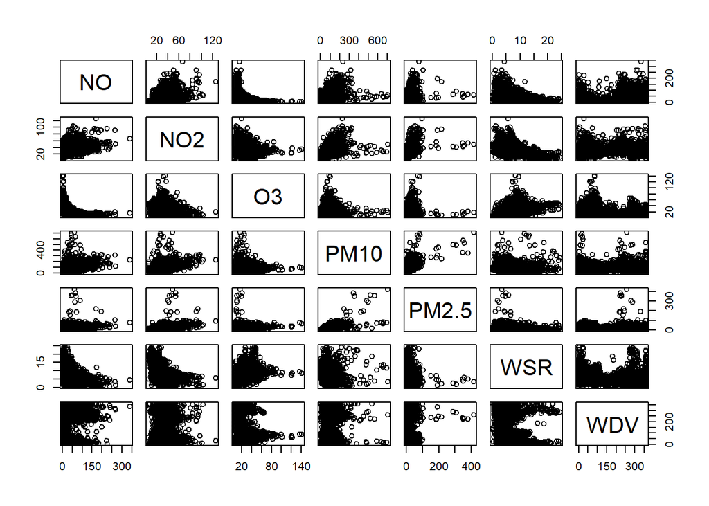

```r
spring_data <- subset(data, season =="spring (MAM)")
summer_data <- subset(data, season == "summer (JJA)")
autumn_data <- subset(data, season== "autumn (SON)")
winter_data <- subset(data, season == "winter (DJF)")

plot(winter_data[-c(1, 9)])
```

Aunque ninguna de las relaciones entre variables es evidentemente lineal, sí hay algunas que podrían tener una buena correlación.

```r
cor(winter_data[-c(1, 9)])
```

```
##               NO        NO2          O3        PM10       PM2.5         WSR
## NO     1.0000000  0.5067607 -0.47621540  0.44285933  0.30651021 -0.32379607
## NO2    0.5067607  1.0000000 -0.26545394  0.50032740  0.40175210 -0.40631249
## O3    -0.4762154 -0.2654539  1.00000000 -0.12071941 -0.01639626  0.45175089
## PM10   0.4428593  0.5003274 -0.12071941  1.00000000  0.65644928 -0.09517261
## PM2.5  0.3065102  0.4017521 -0.01639626  0.65644928  1.00000000 -0.19395032
## WSR   -0.3237961 -0.4063125  0.45175089 -0.09517261 -0.19395032  1.00000000
## WDV    0.2871094  0.1833851 -0.23213106  0.22105684  0.17005773 -0.27662532
##              WDV
## NO     0.2871094
## NO2    0.1833851
## O3    -0.2321311
## PM10   0.2210568
## PM2.5  0.1700577
## WSR   -0.2766253
## WDV    1.0000000
```

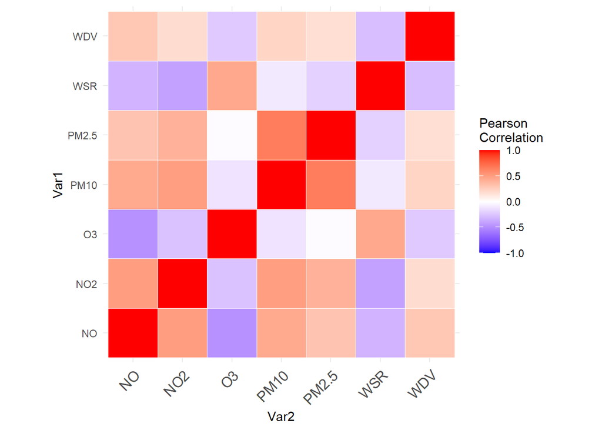

```r
library(ggplot2)
library(reshape2)

ggplot(data = melt(cor(winter_data[-c(1, 9)])), aes(Var2, Var1, fill = value))+
 geom_tile(color = "white")+
 scale_fill_gradient2(low = "blue", high = "red", mid = "white",
   midpoint = 0, limit = c(-1,1), space = "Lab",
   name="Pearson\nCorrelation") +
  theme_minimal()+
 theme(axis.text.x = element_text(angle = 45, vjust = 1,
    size = 12, hjust = 1))+
 coord_fixed()
```

Al estudiar el coeficiente de correlación de Pearson entre las variables se puede notar que el par de variables con mayor correlación es (PM10, PM2.5), con un coeficiente de 0.6564.

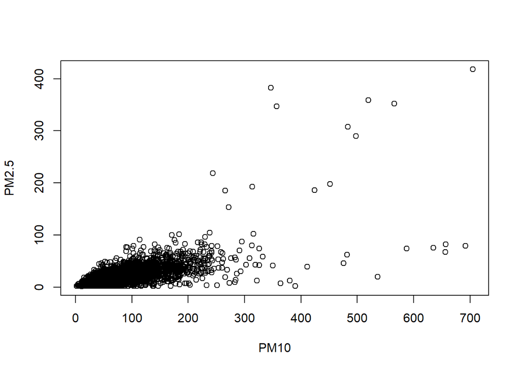

```r
data = winter_data[c('PM10', 'PM2.5')]
plot(data)
```

La relación lineal parece convincente para los intervalos con mayor densidad de puntos, sin embargo, mientras aumentan los valores, la relación se vuelve más difusa.

## Estudio de Valores Atípicos e Influyentes

```r
reg = lm(winter_data$PM2.5 ~ winter_data$PM10)
summary(reg)
```

```
##
## Call:
## lm(formula = winter_data$PM2.5 ~ winter_data$PM10)
##
## Residuals:
##      Min       1Q   Median       3Q      Max
## -109.550   -6.667   -0.742    5.749  298.210
##
## Coefficients:
##                  Estimate Std. Error t value Pr(>|t|)
## (Intercept)       1.19360    0.47719   2.501   0.0124 *
## winter_data$PM10  0.23947    0.00459  52.175   <2e-16 ***
## ---
## Signif. codes:  0 '***' 0.001 '**' 0.01 '*' 0.05 '.' 0.1 ' ' 1
##
## Residual standard error: 16.53 on 3595 degrees of freedom
## Multiple R-squared:  0.4309, Adjusted R-squared:  0.4308
## F-statistic:  2722 on 1 and 3595 DF,  p-value: < 2.2e-16
```

A partir del resumen del modelo de regresión se obtiene el ajuste $r^2 = 0.4308$, un valor muy bajo, pero que posiblemente pueda mejorarse tratando datos atípicos e influyentes.

### Detección de Datos Atípicos

Se busca detectar datos atípicos mediante el criterio de la desviación estándar.

```r
reg.rstandard = rstandard(reg)
```

También se prueba a través del criterio de estandarización extrema.

```r
reg.rstudent = rstudent(reg)
```

### Detección de Datos Influyentes

Primero, por grado de leverage.

```r
reg.hat = hatvalues(reg)
```

Por distancia de cook.

```r
reg.cooks = cooks.distance(reg)
```

### Resultados

```r
reg.residuals = reg$residuals
resultados = data.frame(reg.residuals,
                        reg.rstandard,
                        reg.rstudent,
                        reg.hat,
                        reg.cooks)
head(resultados[order(abs(resultados$reg.residuals), decreasing = TRUE), ])
```

```
##      reg.residuals reg.rstandard reg.rstudent     reg.hat reg.cooks
## 2159      298.2100      18.08637     18.96738 0.005572974 0.9166153
## 2158      260.3153      15.79134     16.36699 0.005984663 0.7506793
## 2160      247.9794      15.22740     15.74139 0.029911360 3.5747539
## 2161      233.2815      14.21507     14.63021 0.014868093 1.5248558
## 1         215.2659      13.13896     13.46439 0.018115887 1.5925426
## 3         191.1420      11.63326     11.85696 0.012492375 0.8560078
```

Como puede verse, existen datos que se encuentran a una distancia de hasta 18 desviaciones estándar de la media, los cuales pueden sin duda considerarse atípicos. Vamos a filtrar y conservar únicamente aquellos que están a menos de tres desviaciones estándar de la media.

La distancia de cook mide la influencia de cada observación en el modelo considerando qué tanto cambiaría este si la observación no estuviera. La matriz hat contiene en su diagonal las distancias relativas desde el centroide de los datos hasta cada uno de los puntos. Las “cotas de influencia” son…

$$\text{Leverage: } \frac{2.5 * (p + 1)}{n} = \frac{2.5 * 3}{3597} =
0.0021$$

$$\text{Distancia Cook } = 1$$

```r
new.data = cbind(winter_data[c(5, 6)], reg.rstudent, reg.hat, reg.cooks)
# Se eliminan aquellos que están muy alejados en términos de desviaciones estándar.
new.data = new.data[new.data$reg.rstudent <= 3, ]
# Se eliminan aquellos que no cumplen el criterio de la distancia de Leverage
new.data = new.data[new.data$reg.hat <= 0.0021, ]
# Se eliminan aquellos que no cumplen el crierio de la distancia de Cook:
new.data = new.data[new.data$reg.cooks <= 1, ]
cat('Porcentaje de observaciones conservadas:', 100 * length(new.data$PM10) / length(winter_data$PM10), "%")
```

```
## Porcentaje de observaciones conservadas: 98.05393 %
```

Una vez eliminados los datos atípicos e influyentes se reajusta el modelo lineal, esperando mejores resultados.

## Nuevo Modelo Lineal

```r
reg = lm(new.data$PM2.5 ~ new.data$PM10)
summary(reg)
```

```
##
## Call:
## lm(formula = new.data$PM2.5 ~ new.data$PM10)
##
## Residuals:
##     Min      1Q  Median      3Q     Max
## -48.131  -6.451  -0.938   5.560  51.441
##
## Coefficients:
##               Estimate Std. Error t value Pr(>|t|)
## (Intercept)   3.666023   0.354375   10.35   <2e-16 ***
## new.data$PM10 0.205431   0.003856   53.27   <2e-16 ***
## ---
## Signif. codes:  0 '***' 0.001 '**' 0.01 '*' 0.05 '.' 0.1 ' ' 1
##
## Residual standard error: 10.38 on 3525 degrees of freedom
## Multiple R-squared:  0.446,  Adjusted R-squared:  0.4459
## F-statistic:  2838 on 1 and 3525 DF,  p-value: < 2.2e-16
```

El modelo tiene un ajuste $r^2 = 0.4459$, que es ligeramente superior al ajuste original con los datos atípicos e influyentes, pero sigue sin ser un ajuste aceptable apriori, pues explica muy poco sobre la relación de los datos, aunque quizá no es la mejor métrica para datos que a simple vista no son homocedásticos.

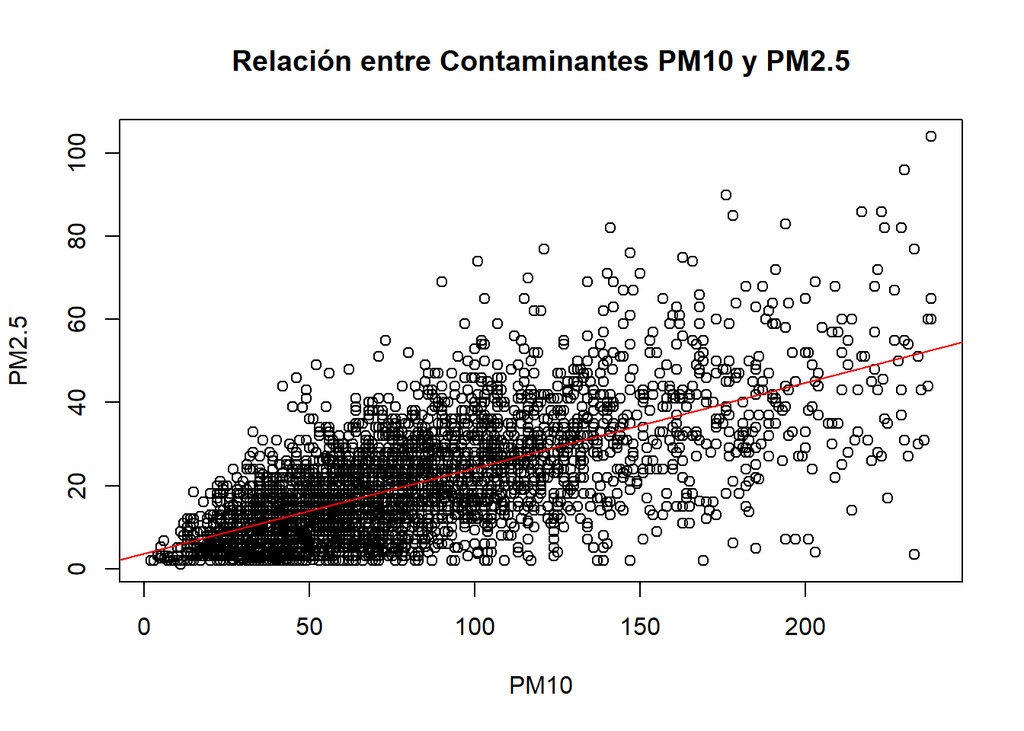

```r
plot(new.data[c('PM10', 'PM2.5')], main = "Relación entre Contaminantes PM10 y PM2.5")
abline(reg, col="red")
```

## Validación del Modelo

### Media Cero en los Residuos

Se realiza una prueba de hipótesis para media.

$$H_0: \mu_R = 0$$

$$H_1:\mu_R\neq 0$$

```r
t.test(reg$residuals)
```

```
##
##  One Sample t-test
##
## data:  reg$residuals
## t = -4.8888e-15, df = 3526, p-value = 1
## alternative hypothesis: true mean is not equal to 0
## 95 percent confidence interval:
##  -0.3427365  0.3427365
## sample estimates:
##     mean of x
## -8.546067e-16
```

Ya que el valor-p es mayor que el nivel de significancia, se conserva la hipótesis nula y se concluye que no hay suficiente evidencia estadística para descartar que la media de los residuos es cero. Se cumple el supuesto.

### Normalidad de los Residuos

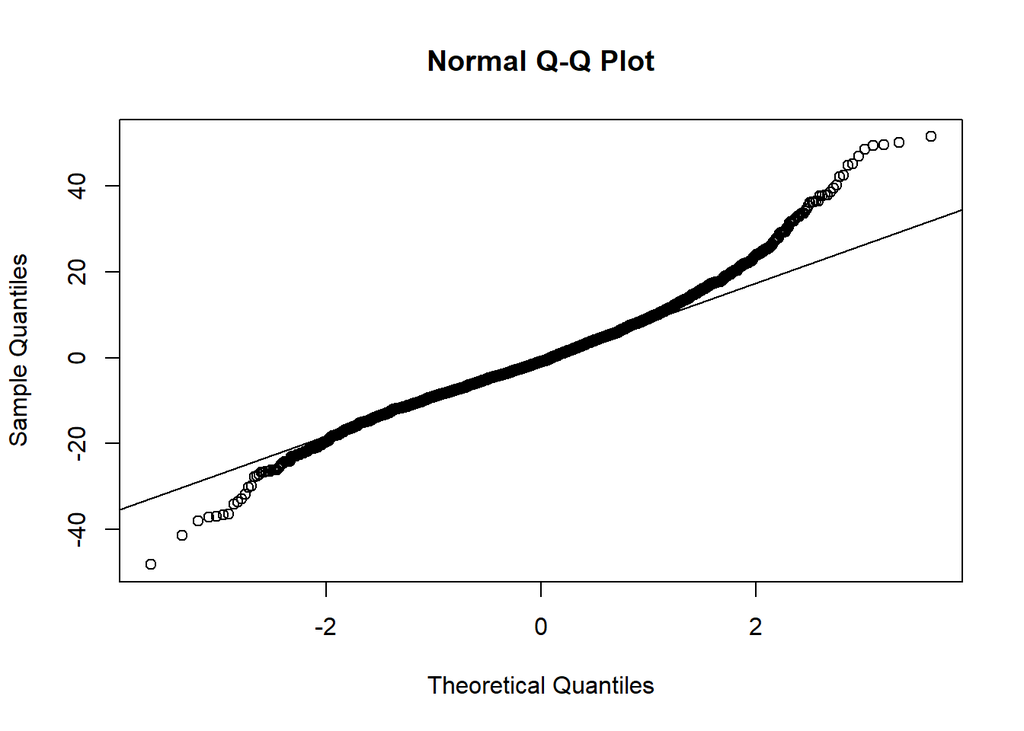

```r
qqnorm(reg$residuals)
qqline(reg$residuals)
```

La prueba de normalidad de Shapiro-Wilk se basa en las siguientes hipótesis:

- $H_0:$ La distribución es normal.
- $H_1:$ La distribución NO es normal.

```r
shapiro.test(reg$residuals)
```

```
##
##  Shapiro-Wilk normality test
##
## data:  reg$residuals
## W = 0.9738, p-value < 2.2e-16
```

Siendo el valor-p notablemente menor que el nivel de significancia $\alpha = 0.05$, se rechaza la hipótesis nula y se concluye que existe evidencia estadística para negar que los residuos se distribuyen normalmente. No pasó la prueba.

### Homocedasticidad

Se implementan la prueba de Breusch-Pagan, además del test de White, la cual es una prueba más robusta que detecta formas no lineales de la heterocedasticidad.

Estos test busca determinar la homocedasticidad, es decir, si la varianza de los residuos depende o no de los valores de las variables predictoras (o la variable predictora, como en este caso). Para ello, se establecen las siguientes hipótesis:

- $H_0: \text{Se cumple homocedasticidad.}$
- $H_1: \text{No se cumple la homocedasticidad.}$

```r
library(lmtest)
#Prueba Breusch-Pagan:
bptest(reg)
```

```
##
##  studentized Breusch-Pagan test
##
## data:  reg
## BP = 421.73, df = 1, p-value < 2.2e-16
```

```r
#Prueba de White:
bptest(reg, varformula = ~ new.data$PM10 * new.data$PM2.5 + I(new.data$PM10^2) + I(new.data$PM2.5^2))
```

```
##
##  studentized Breusch-Pagan test
##
## data:  reg
## BP = 3527, df = 5, p-value < 2.2e-16
```

Ya que el valor-p en ambos test es notablemente menor que el nivel de significancia, se rechaza la hipótesis nula, y se concluye que existe evidencia estadística para descartar que los residuos sean homocedásticos. No se cumple el supuesto.

## Conclusión Apriori

Ya que dos de los supuestos mas importantes de la regresión lineal (normalidad y homocedasticidad de los residuos) no se cumplen, se determina que la regresión lineal no es un buen modelo para entender la relación entre las partículas PM10 y PM2.5

## Estandarización de Datos

```r
new.data$PM10 = scale(new.data$PM10)
new.data$PM2.5 = scale(new.data$PM2.5)
head(new.data)
```

```
##           PM10      PM2.5 reg.rstudent      reg.hat    reg.cooks
## 5   3.02271949  4.7255460    1.9886858 0.0016234261 3.212800e-03
## 6   1.89800542  3.8652194    2.0007587 0.0007852895 1.571693e-03
## 7   0.57481239  1.4993210    0.8723871 0.0003124374 1.189367e-04
## 8   0.08964161 -0.2930262   -0.3211054 0.0002780668 1.434312e-05
## 9   0.19990769  1.0691577    0.7556735 0.0002793285 7.978604e-05
## 10 -0.21910343  0.9974638    0.9704512 0.0002950306 1.389696e-04
```

## Último Modelo Lineal Estandarizado

```r
reg = lm(new.data$PM2.5 ~ new.data$PM10)
summary(reg)
```

```
##
## Call:
## lm(formula = new.data$PM2.5 ~ new.data$PM10)
##
## Residuals:
##     Min      1Q  Median      3Q     Max
## -3.4507 -0.4625 -0.0672  0.3986  3.6880
##
## Coefficients:
##                Estimate Std. Error t value Pr(>|t|)
## (Intercept)   1.125e-14  1.253e-02    0.00        1
## new.data$PM10 6.678e-01  1.254e-02   53.27   <2e-16 ***
## ---
## Signif. codes:  0 '***' 0.001 '**' 0.01 '*' 0.05 '.' 0.1 ' ' 1
##
## Residual standard error: 0.7444 on 3525 degrees of freedom
## Multiple R-squared:  0.446,  Adjusted R-squared:  0.4459
## F-statistic:  2838 on 1 and 3525 DF,  p-value: < 2.2e-16
```

El modelo tiene un ajuste $r^2 = 0.4459$, que es ligeramente superior al ajuste original con los datos atípicos e influyentes, pero sigue sin ser un ajuste aceptable apriori, pues explica muy poco sobre la relación de los datos, aunque quizá no es la mejor métrica para datos que a simple vista no son homocedásticos.

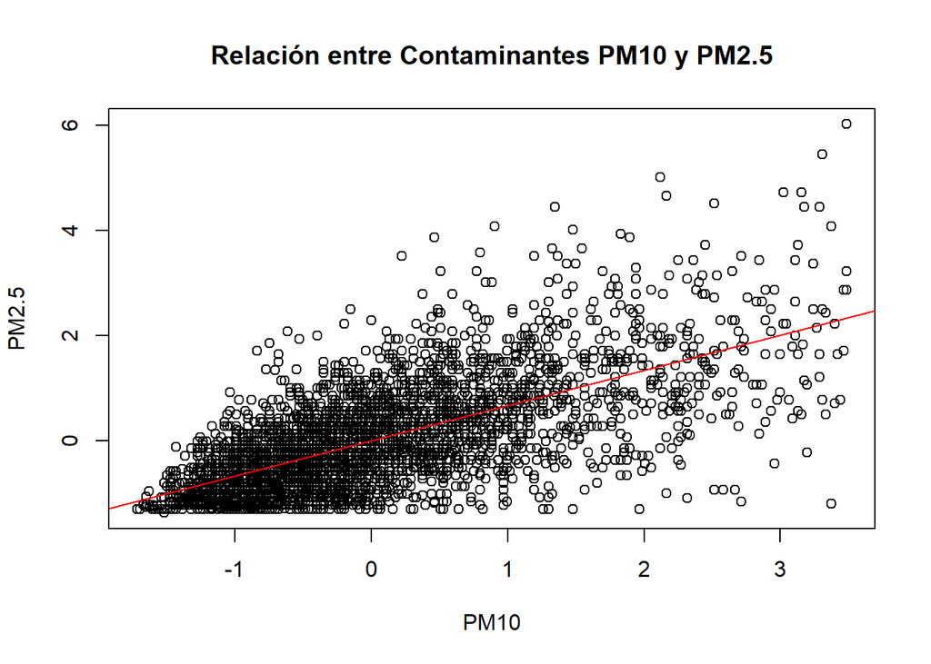

```r
plot(new.data[c('PM10', 'PM2.5')], main = "Relación entre Contaminantes PM10 y PM2.5")
abline(reg, col="red")
```

## Validación del Modelo

### Media Cero en los Residuos

Se realiza una prueba de hipótesis para media.

$$H_0: \mu_R = 0$$

$$H_1:\mu_R\neq 0$$

```r
t.test(reg$residuals)
```

```
##
##  One Sample t-test
##
## data:  reg$residuals
## t = -6.6517e-15, df = 3526, p-value = 1
## alternative hypothesis: true mean is not equal to 0
## 95 percent confidence interval:
##  -0.02457211  0.02457211
## sample estimates:
##     mean of x
## -8.336433e-17
```

Ya que el valor-p es mayor que el nivel de significancia, se conserva la hipótesis nula y se concluye que no hay suficiente evidencia estadística para descartar que la media de los residuos es cero. Se cumple el supuesto.

### Normalidad de los Residuos

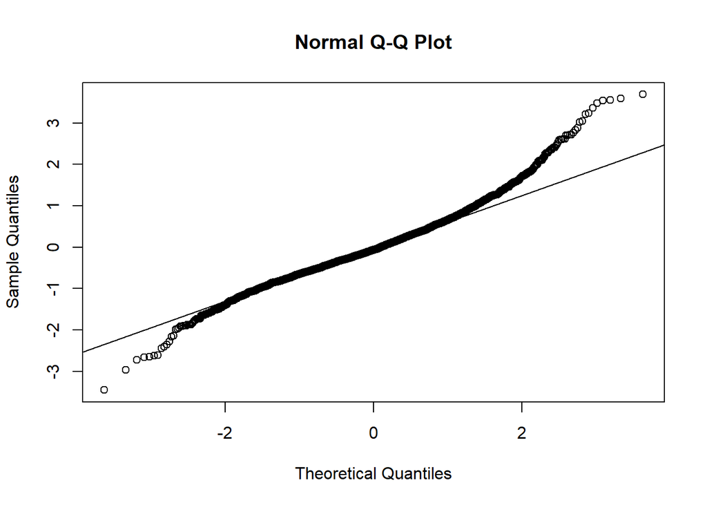

```r
qqnorm(reg$residuals)
qqline(reg$residuals)
```

La prueba de normalidad de Shapiro-Wilk se basa en las siguientes hipótesis:

- $H_0:$ La distribución es normal.
- $H_1:$ La distribución NO es normal.

```r
shapiro.test(reg$residuals)
```

```
##
##  Shapiro-Wilk normality test
##
## data:  reg$residuals
## W = 0.9738, p-value < 2.2e-16
```

Siendo el valor-p notablemente menor que el nivel de significancia $\alpha = 0.05$, se rechaza la hipótesis nula y se concluye que existe evidencia estadística para negar que los residuos se distribuyen normalmente. No pasó la prueba.

### Homocedasticidad

Se implementan la prueba de Breusch-Pagan, además del test de White, la cual es una prueba más robusta que detecta formas no lineales de la heterocedasticidad.

Estos test busca determinar la homocedasticidad, es decir, si la varianza de los residuos depende o no de los valores de las variables predictoras (o la variable predictora, como en este caso). Para ello, se establecen las siguientes hipótesis:

- $H_0: \text{Se cumple homocedasticidad.}$
- $H_1: \text{No se cumple la homocedasticidad.}$

```r
library(lmtest)
#Prueba Breusch-Pagan:
bptest(reg)
```

```
##
##  studentized Breusch-Pagan test
##
## data:  reg
## BP = 421.73, df = 1, p-value < 2.2e-16
```

```r
#Prueba de White:
bptest(reg, varformula = ~ new.data$PM10 * new.data$PM2.5 + I(new.data$PM10^2) + I(new.data$PM2.5^2))
```

```
##
##  studentized Breusch-Pagan test
##
## data:  reg
## BP = 3527, df = 5, p-value < 2.2e-16
```

Ya que el valor-p en ambos test es notablemente menor que el nivel de significancia, se rechaza la hipótesis nula, y se concluye que existe evidencia estadística para descartar que los residuos sean homocedásticos. No se cumple el supuesto.

## Conclusión

Puesto que la estandarización no funcionó tampoco, se concluye que la relación entre estas variables no puede ser explicada simplemente mediante regresión lineal.